# House data research at Saratoga, New York

Aplus Group

# Introduction

## Description

Rebecca and Haofei are Psychology student and Linda is from Gies College of Business. We are all born in China. In China, housing price is super high compared to the income of an average individual. Many factors including heavy financial bubbles in the capital market have result in the high price of properties. We are all curious of factors that influence the housing price in the United States. This dataset from [The Data And Story Library](https://dasl.datadescription.com/) contains the housing price at Saratoga, New York, as well as seven attributes of the property. We are going to find the best predictors of the housing price, while the model with all predictors seems to be insufficient due to violation of equal variance and normality… We are trying to find the composition of the housing price.

This dataset contains 1057 observations and 8 variables:

**Numerical Response**

- `Price`: The price of this property in U.S. dollars.

**Numerical Predictors**

- `Living.Area`: The size of this property in square feet.
- `Bathrooms`: Number of bathrooms in this property.
- `Bedrooms`: Number of bedrooms in this property.
- `Fireplaces`: Number of fireplaces in this property.
- `Lot.Size`: The total area of a property, including the yard up to the boundaries (property line) in arce.
- `Age`: The age of the property.

**Factor Predictor**

- `Fireplace`: Whether there is a fireplace in the house.

# Methods

## Preparation of Data

```r
library(readr)
housing = read.csv("housing-prices.csv")
names(housing)
```

```
## [1] "Price"       "Living.Area" "Bathrooms"   "Bedrooms"    "Fireplaces"
## [6] "Lot.Size"    "Age"         "Fireplace"
```

```r
housing$Fireplace = as.factor(housing$Fireplace)
str(housing)
```

```
## 'data.frame':    1057 obs. of  8 variables:
##  $ Price      : int  142212 134865 118007 138297 129470 206512 50709 108794 68353 123266 ...
##  $ Living.Area: int  1982 1676 1694 1800 2088 1456 960 1464 1216 1632 ...
##  $ Bathrooms  : num  1 1.5 2 1 1 2 1.5 1 1 1.5 ...
##  $ Bedrooms   : int  3 3 3 2 3 3 2 2 2 3 ...
##  $ Fireplaces : int  0 1 1 2 1 0 0 0 0 0 ...
##  $ Lot.Size   : num  2 0.38 0.96 0.48 1.84 0.98 NA 0.11 0.61 0.23 ...
##  $ Age        : int  133 14 15 49 29 10 12 87 101 14 ...
##  $ Fireplace  : Factor w/ 2 levels "FALSE","TRUE": 1 2 2 2 2 1 1 1 1 1 ...
```

We converted the Fireplace variable from logical to the factor type. Factor level 1 stands for no presence of fireplace (FALSE). Factor level 2 stands for presence of fireplace (TRUE).

```r
sum(is.na(housing))
```

```
## [1] 9
```

```r
apply(is.na(housing), 2, which)
```

```
## $Price
## integer(0)
##
## $Living.Area
## integer(0)
##
## $Bathrooms
## integer(0)
##
## $Bedrooms
## integer(0)
##
## $Fireplaces
## integer(0)
##
## $Lot.Size
## [1]    7  129  252  413  427  478  502  741 1037
##
## $Age
## integer(0)
##
## $Fireplace
## integer(0)
```

```r
#na.omit(housing)
# all from Lot.size

#install.packages("Hmisc")

library(Hmisc)
```

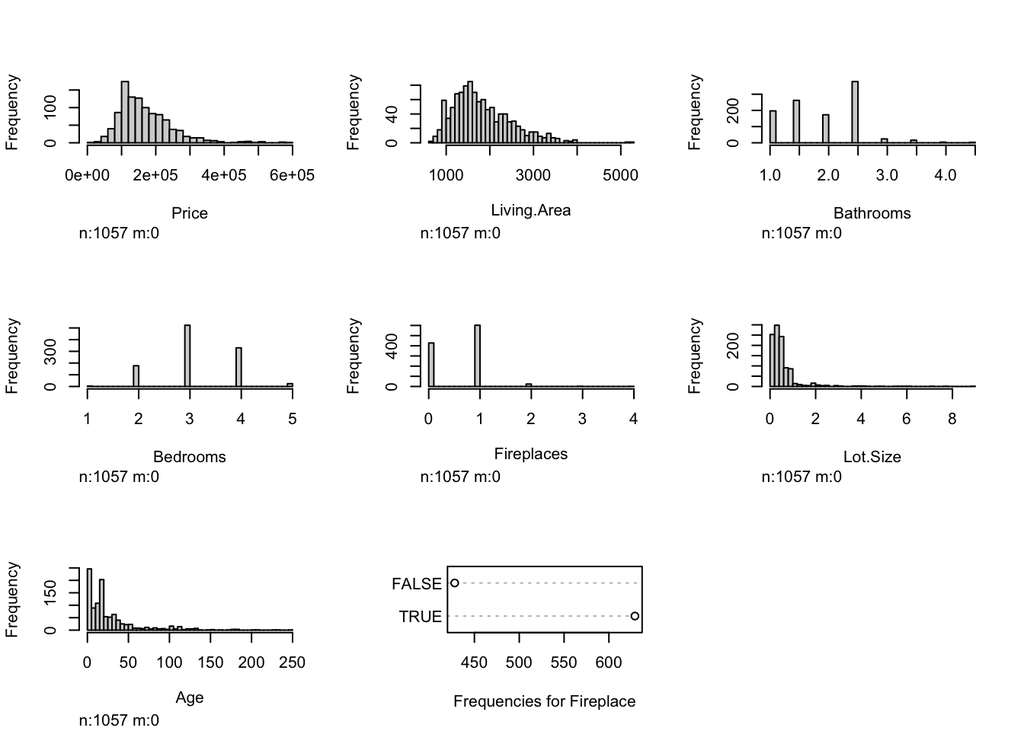

```r
housing$Lot.Size[is.na(housing$Lot.Size)] = median(housing$Lot.Size, na.rm = T)

hist(housing)
```

```r
#low variation -> use imputation median
```

We identified the number of missing values for this dataset. The results show all missing values to be under the Lot.size category.

## Multiple Linear Regression

```r
#install.packages("leaps", "https://cloud.r-project.org/")
library(leaps)
housing_mod_mlr = lm(Price ~., data = housing)
# multiple regression
summary(housing_mod_mlr)
```

```
##
## Call:
## lm(formula = Price ~ ., data = housing)
##
## Residuals:
##     Min      1Q  Median      3Q     Max
## -207215  -23844   -5149   16340  392304
##
## Coefficients:
##                Estimate Std. Error t value Pr(>|t|)
## (Intercept)   15582.762   7324.692   2.127  0.03362 *
## Living.Area      72.759      4.081  17.829  < 2e-16 ***
## Bathrooms     19581.617   3688.743   5.308 1.35e-07 ***
## Bedrooms      -6029.734   2774.982  -2.173  0.03001 *
## Fireplaces    15695.590   8041.056   1.952  0.05121 .
## Lot.Size        723.090   1999.556   0.362  0.71770
## Age            -148.204     48.628  -3.048  0.00236 **
## FireplaceTRUE -7861.179   8901.311  -0.883  0.37736
## ---
## Signif. codes:  0 '***' 0.001 '**' 0.01 '*' 0.05 '.' 0.1 ' ' 1
##
## Residual standard error: 48640 on 1049 degrees of freedom
## Multiple R-squared:  0.6052, Adjusted R-squared:  0.6026
## F-statistic: 229.8 on 7 and 1049 DF,  p-value: < 2.2e-16
```

```r
summary(housing_mod_mlr)$r.squared
```

```
## [1] 0.6052342
```

```r
anova(housing_mod_mlr)
```

```
## Analysis of Variance Table
##
## Response: Price
##               Df     Sum Sq    Mean Sq   F value    Pr(>F)
## Living.Area    1 3.6186e+12 3.6186e+12 1529.4906 < 2.2e-16 ***
## Bathrooms      1 1.1869e+11 1.1869e+11   50.1690 2.582e-12 ***
## Bedrooms       1 2.2942e+10 2.2942e+10    9.6971  0.001896 **
## Fireplaces     1 2.1853e+10 2.1853e+10    9.2366  0.002431 **
## Lot.Size       1 1.8822e+08 1.8822e+08    0.0796  0.777958
## Age            1 2.0864e+10 2.0864e+10    8.8186  0.003050 **
## Fireplace      1 1.8453e+09 1.8453e+09    0.7800  0.377358
## Residuals   1049 2.4818e+12 2.3659e+09
## ---
## Signif. codes:  0 '***' 0.001 '**' 0.01 '*' 0.05 '.' 0.1 ' ' 1
```

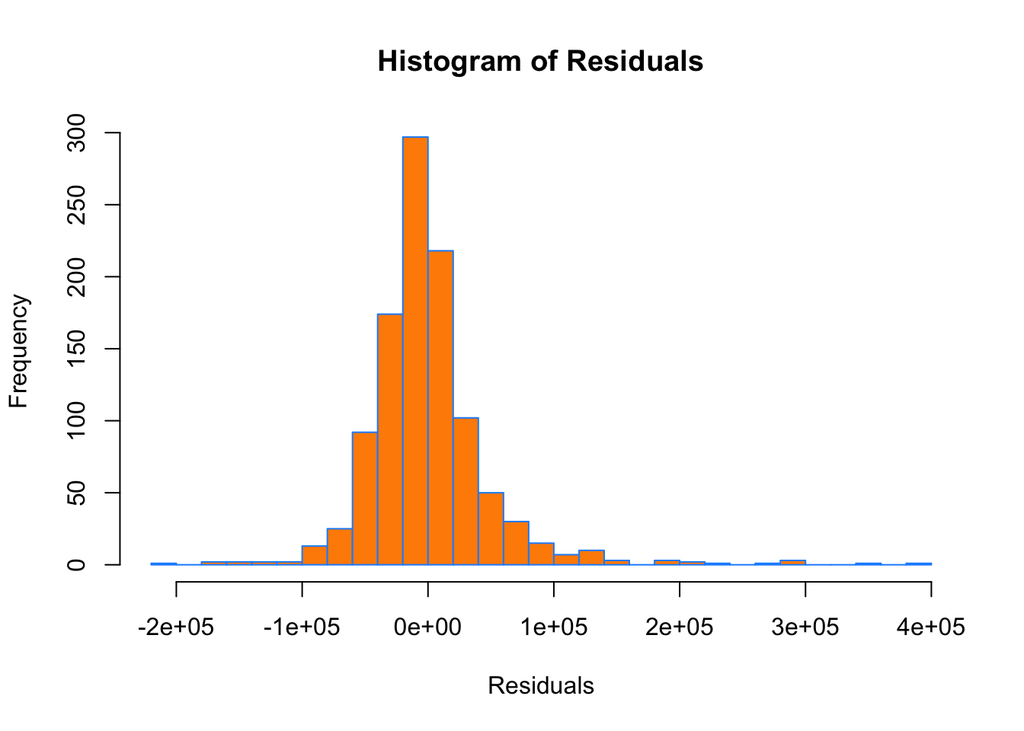

```r
hist(resid(housing_mod_mlr),
     xlab   = "Residuals",
     main   = "Histogram of Residuals",
     col    = "darkorange",
     border = "dodgerblue",
     breaks = 25)
```

```r
sub = summary(regsubsets(Price ~., data = housing))
sub$which
```

```
##   (Intercept) Living.Area Bathrooms Bedrooms Fireplaces Lot.Size   Age
## 1        TRUE        TRUE     FALSE    FALSE      FALSE    FALSE FALSE
## 2        TRUE        TRUE      TRUE    FALSE      FALSE    FALSE FALSE
## 3        TRUE        TRUE      TRUE    FALSE      FALSE    FALSE  TRUE
## 4        TRUE        TRUE      TRUE    FALSE       TRUE    FALSE  TRUE
## 5        TRUE        TRUE      TRUE     TRUE       TRUE    FALSE  TRUE
## 6        TRUE        TRUE      TRUE     TRUE       TRUE    FALSE  TRUE
## 7        TRUE        TRUE      TRUE     TRUE       TRUE     TRUE  TRUE
##   FireplaceTRUE
## 1         FALSE
## 2         FALSE
## 3         FALSE
## 4         FALSE
## 5         FALSE
## 6          TRUE
## 7          TRUE
```

```r
sub$rss
```

```
## [1] 2.668201e+12 2.549507e+12 2.518787e+12 2.496701e+12 2.484049e+12
## [6] 2.482124e+12 2.481815e+12
```

```r
sub$adjr2
```

```
## [1] 0.5751846 0.5936973 0.5982118 0.6013563 0.6029989 0.6029289 0.6025999
```

```r
best_r2 = which.max(sub$adjr2)

n = length(resid(housing_mod_mlr))
p = length(coef(housing_mod_mlr))
sub_aic = (n * log(sub$rss / n) + 2 * (2:p))
sub$which[which.min(sub_aic), ]
```

```
##   (Intercept)   Living.Area     Bathrooms      Bedrooms    Fireplaces
##          TRUE          TRUE          TRUE          TRUE          TRUE
##      Lot.Size           Age FireplaceTRUE
##         FALSE          TRUE         FALSE
```

```r
housing_mod_back_aic = step(housing_mod_mlr, direction = "backward", trace = 0)
summary(housing_mod_back_aic)
```

```
##
## Call:
## lm(formula = Price ~ Living.Area + Bathrooms + Bedrooms + Fireplaces +
##     Age, data = housing)
##
## Residuals:
##     Min      1Q  Median      3Q     Max
## -203004  -23922   -5153   16497  392655
##
## Coefficients:
##              Estimate Std. Error t value Pr(>|t|)
## (Intercept) 15712.702   7311.427   2.149  0.03186 *
## Living.Area    73.446      4.009  18.321  < 2e-16 ***
## Bathrooms   19236.678   3669.080   5.243 1.91e-07 ***
## Bedrooms    -6361.311   2749.503  -2.314  0.02088 *
## Fireplaces   9162.791   3194.233   2.869  0.00421 **
## Age          -142.739     48.276  -2.957  0.00318 **
## ---
## Signif. codes:  0 '***' 0.001 '**' 0.01 '*' 0.05 '.' 0.1 ' ' 1
##
## Residual standard error: 48620 on 1051 degrees of freedom
## Multiple R-squared:  0.6049, Adjusted R-squared:  0.603
## F-statistic: 321.8 on 5 and 1051 DF,  p-value: < 2.2e-16
```

```r
n = length(resid(housing_mod_mlr))
housing_mod_back_bic = step(housing_mod_mlr, direction = "backward", k = log(n), trace = 0)
summary(housing_mod_back_bic)
```

```
##
## Call:
## lm(formula = Price ~ Living.Area + Bathrooms + Fireplaces + Age,
##     data = housing)
##
## Residuals:
##     Min      1Q  Median      3Q     Max
## -197443  -23986   -5519   15055  395949
##
## Coefficients:
##              Estimate Std. Error t value Pr(>|t|)
## (Intercept)  5656.338   5891.278   0.960 0.337215
## Living.Area    68.946      3.513  19.628  < 2e-16 ***
## Bathrooms   18274.055   3652.947   5.003 6.63e-07 ***
## Fireplaces   9735.036   3191.224   3.051 0.002341 **
## Age          -161.022     47.723  -3.374 0.000768 ***
## ---
## Signif. codes:  0 '***' 0.001 '**' 0.01 '*' 0.05 '.' 0.1 ' ' 1
##
## Residual standard error: 48720 on 1052 degrees of freedom
## Multiple R-squared:  0.6029, Adjusted R-squared:  0.6014
## F-statistic: 399.2 on 4 and 1052 DF,  p-value: < 2.2e-16
```

```r
anova(housing_mod_back_bic, housing_mod_back_aic)
```

```
## Analysis of Variance Table
##
## Model 1: Price ~ Living.Area + Bathrooms + Fireplaces + Age
## Model 2: Price ~ Living.Area + Bathrooms + Bedrooms + Fireplaces + Age
##   Res.Df        RSS Df  Sum of Sq      F  Pr(>F)
## 1   1052 2.4967e+12
## 2   1051 2.4840e+12  1 1.2652e+10 5.3528 0.02088 *
## ---
## Signif. codes:  0 '***' 0.001 '**' 0.01 '*' 0.05 '.' 0.1 ' ' 1
```

```r
mod2 = lm(Price ~ Living.Area + Bathrooms + Bedrooms + Fireplaces + Age + Bathrooms:Bedrooms, data = housing)
summary(mod2)
```

```
##
## Call:
## lm(formula = Price ~ Living.Area + Bathrooms + Bedrooms + Fireplaces +
##     Age + Bathrooms:Bedrooms, data = housing)
##
## Residuals:
##     Min      1Q  Median      3Q     Max
## -182939  -24828   -5498   16370  387744
##
## Coefficients:
##                      Estimate Std. Error t value Pr(>|t|)
## (Intercept)         91997.207  20423.383   4.505 7.40e-06 ***
## Living.Area            69.791      4.084  17.088  < 2e-16 ***
## Bathrooms          -21015.122  10711.259  -1.962  0.05003 .
## Bedrooms           -29222.144   6338.779  -4.610 4.52e-06 ***
## Fireplaces           9397.336   3172.269   2.962  0.00312 **
## Age                  -149.999     47.970  -3.127  0.00182 **
## Bathrooms:Bedrooms  12658.898   3167.770   3.996 6.89e-05 ***
## ---
## Signif. codes:  0 '***' 0.001 '**' 0.01 '*' 0.05 '.' 0.1 ' ' 1
##
## Residual standard error: 48270 on 1050 degrees of freedom
## Multiple R-squared:  0.6108, Adjusted R-squared:  0.6086
## F-statistic: 274.6 on 6 and 1050 DF,  p-value: < 2.2e-16
```

```r
anova(housing_mod_mlr,mod2)
```

```
## Analysis of Variance Table
##
## Model 1: Price ~ Living.Area + Bathrooms + Bedrooms + Fireplaces + Lot.Size +
##     Age + Fireplace
## Model 2: Price ~ Living.Area + Bathrooms + Bedrooms + Fireplaces + Age +
##     Bathrooms:Bedrooms
##   Res.Df        RSS Df  Sum of Sq F Pr(>F)
## 1   1049 2.4818e+12
## 2   1050 2.4468e+12 -1 3.4979e+10
```

- The test statistic: $F$ = 5.3528
- The distribution of the test statistic under the null hypothesis: $F$ distribution with df = 1 and 1051.
- The p-value: $p$ = 0.02088
- A decision: We reject the null hypothesis under the significance $\alpha = 0.05$. The model selected by backward AIC variable selection is better.

```r
summary(housing_mod_back_aic)$adj.r.squared
```

```
## [1] 0.6029989
```

```r
summary(housing_mod_back_bic)$adj.r.squared
```

```
## [1] 0.6013563
```

Also seen by the larger adjusted R^2, the better model is the model with backward AIC variable selection.

## Interaction

```r
#interaction
housing_mod_int = lm(Price ~ Living.Area * Bathrooms * Bedrooms * Fireplaces * Lot.Size * Age * Fireplace, data = housing)
#summary(housing_mod_int)

housing_mod_int_aic = step(housing_mod_int, direction = "backward", trace = 0)
n = length(resid(housing_mod_int))
housing_mod_int_bic = step(housing_mod_int, direction = "backward", k = log(n), trace = 0)
anova(housing_mod_int_bic, housing_mod_int_aic)
```

```
## Analysis of Variance Table
##
## Model 1: Price ~ Living.Area + Bathrooms + Bedrooms + Fireplaces + Lot.Size +
##     Age + Fireplace + Living.Area:Bathrooms + Living.Area:Bedrooms +
##     Bathrooms:Bedrooms + Living.Area:Fireplaces + Bathrooms:Fireplaces +
##     Bedrooms:Fireplaces + Living.Area:Lot.Size + Bathrooms:Lot.Size +
##     Bedrooms:Lot.Size + Fireplaces:Lot.Size + Living.Area:Age +
##     Bathrooms:Age + Bedrooms:Age + Fireplaces:Age + Lot.Size:Age +
##     Living.Area:Fireplace + Bathrooms:Fireplace + Age:Fireplace +
##     Living.Area:Bathrooms:Bedrooms + Living.Area:Bathrooms:Fireplaces +
##     Living.Area:Bedrooms:Fireplaces + Bathrooms:Bedrooms:Fireplaces +
##     Living.Area:Bathrooms:Lot.Size + Living.Area:Bedrooms:Lot.Size +
##     Bathrooms:Bedrooms:Lot.Size + Living.Area:Fireplaces:Lot.Size +
##     Bathrooms:Fireplaces:Lot.Size + Bedrooms:Fireplaces:Lot.Size +
##     Living.Area:Bathrooms:Age + Living.Area:Bedrooms:Age + Bathrooms:Bedrooms:Age +
##     Living.Area:Fireplaces:Age + Bathrooms:Fireplaces:Age + Bedrooms:Fireplaces:Age +
##     Living.Area:Lot.Size:Age + Bathrooms:Lot.Size:Age + Bedrooms:Lot.Size:Age +
##     Fireplaces:Lot.Size:Age + Living.Area:Bathrooms:Fireplace +
##     Living.Area:Age:Fireplace + Bathrooms:Age:Fireplace + Living.Area:Bathrooms:Bedrooms:Fireplaces +
##     Living.Area:Bathrooms:Bedrooms:Lot.Size + Living.Area:Bathrooms:Fireplaces:Lot.Size +
##     Living.Area:Bedrooms:Fireplaces:Lot.Size + Bathrooms:Bedrooms:Fireplaces:Lot.Size +
##     Living.Area:Bathrooms:Bedrooms:Age + Living.Area:Bathrooms:Fireplaces:Age +
##     Living.Area:Bedrooms:Fireplaces:Age + Bathrooms:Bedrooms:Fireplaces:Age +
##     Living.Area:Bathrooms:Lot.Size:Age + Living.Area:Bedrooms:Lot.Size:Age +
##     Bathrooms:Bedrooms:Lot.Size:Age + Living.Area:Fireplaces:Lot.Size:Age +
##     Bathrooms:Fireplaces:Lot.Size:Age + Bedrooms:Fireplaces:Lot.Size:Age +
##     Living.Area:Bathrooms:Age:Fireplace + Living.Area:Bathrooms:Bedrooms:Fireplaces:Lot.Size +
##     Living.Area:Bathrooms:Bedrooms:Fireplaces:Age + Living.Area:Bathrooms:Bedrooms:Lot.Size:Age +
##     Living.Area:Bathrooms:Fireplaces:Lot.Size:Age + Living.Area:Bedrooms:Fireplaces:Lot.Size:Age +
##     Bathrooms:Bedrooms:Fireplaces:Lot.Size:Age + Living.Area:Bathrooms:Bedrooms:Fireplaces:Lot.Size:Age
## Model 2: Price ~ Living.Area + Bathrooms + Bedrooms + Fireplaces + Lot.Size +
##     Age + Fireplace + Living.Area:Bathrooms + Living.Area:Bedrooms +
##     Bathrooms:Bedrooms + Living.Area:Fireplaces + Bathrooms:Fireplaces +
##     Bedrooms:Fireplaces + Living.Area:Lot.Size + Bathrooms:Lot.Size +
##     Bedrooms:Lot.Size + Fireplaces:Lot.Size + Living.Area:Age +
##     Bathrooms:Age + Bedrooms:Age + Fireplaces:Age + Lot.Size:Age +
##     Living.Area:Fireplace + Bathrooms:Fireplace + Bedrooms:Fireplace +
##     Lot.Size:Fireplace + Age:Fireplace + Living.Area:Bathrooms:Bedrooms +
##     Living.Area:Bathrooms:Fireplaces + Living.Area:Bedrooms:Fireplaces +
##     Bathrooms:Bedrooms:Fireplaces + Living.Area:Bathrooms:Lot.Size +
```

[output cut: 10 more lines]

```
##     Living.Area:Bathrooms:Bedrooms:Lot.Size + Living.Area:Bathrooms:Fireplaces:Lot.Size +
##     Living.Area:Bedrooms:Fireplaces:Lot.Size + Bathrooms:Bedrooms:Fireplaces:Lot.Size +
##     Living.Area:Bathrooms:Bedrooms:Age + Living.Area:Bathrooms:Fireplaces:Age +
##     Living.Area:Bedrooms:Fireplaces:Age + Bathrooms:Bedrooms:Fireplaces:Age +
##     Living.Area:Bathrooms:Lot.Size:Age + Living.Area:Bedrooms:Lot.Size:Age +
##     Bathrooms:Bedrooms:Lot.Size:Age + Living.Area:Fireplaces:Lot.Size:Age +
##     Bathrooms:Fireplaces:Lot.Size:Age + Bedrooms:Fireplaces:Lot.Size:Age +
##     Living.Area:Bathrooms:Lot.Size:Fireplace + Living.Area:Bedrooms:Lot.Size:Fireplace +
##     Living.Area:Bathrooms:Age:Fireplace + Living.Area:Bathrooms:Bedrooms:Fireplaces:Lot.Size +
##     Living.Area:Bathrooms:Bedrooms:Fireplaces:Age + Living.Area:Bathrooms:Bedrooms:Lot.Size:Age +
##     Living.Area:Bathrooms:Fireplaces:Lot.Size:Age + Living.Area:Bedrooms:Fireplaces:Lot.Size:Age +
##     Bathrooms:Bedrooms:Fireplaces:Lot.Size:Age + Living.Area:Bathrooms:Bedrooms:Fireplaces:Lot.Size:Age
##   Res.Df        RSS Df  Sum of Sq      F Pr(>F)
## 1    985 1.9169e+12
## 2    976 1.8960e+12  9 2.0883e+10 1.1944 0.2947
```

```r
summary(housing_mod_int_bic)$adj.r.squared
```

```
## [1] 0.6731097
```

```r
anova(housing_mod_back_aic, housing_mod_int_bic)
```

```
## Analysis of Variance Table
##
## Model 1: Price ~ Living.Area + Bathrooms + Bedrooms + Fireplaces + Age
## Model 2: Price ~ Living.Area + Bathrooms + Bedrooms + Fireplaces + Lot.Size +
##     Age + Fireplace + Living.Area:Bathrooms + Living.Area:Bedrooms +
##     Bathrooms:Bedrooms + Living.Area:Fireplaces + Bathrooms:Fireplaces +
##     Bedrooms:Fireplaces + Living.Area:Lot.Size + Bathrooms:Lot.Size +
##     Bedrooms:Lot.Size + Fireplaces:Lot.Size + Living.Area:Age +
##     Bathrooms:Age + Bedrooms:Age + Fireplaces:Age + Lot.Size:Age +
##     Living.Area:Fireplace + Bathrooms:Fireplace + Age:Fireplace +
##     Living.Area:Bathrooms:Bedrooms + Living.Area:Bathrooms:Fireplaces +
##     Living.Area:Bedrooms:Fireplaces + Bathrooms:Bedrooms:Fireplaces +
##     Living.Area:Bathrooms:Lot.Size + Living.Area:Bedrooms:Lot.Size +
##     Bathrooms:Bedrooms:Lot.Size + Living.Area:Fireplaces:Lot.Size +
##     Bathrooms:Fireplaces:Lot.Size + Bedrooms:Fireplaces:Lot.Size +
##     Living.Area:Bathrooms:Age + Living.Area:Bedrooms:Age + Bathrooms:Bedrooms:Age +
##     Living.Area:Fireplaces:Age + Bathrooms:Fireplaces:Age + Bedrooms:Fireplaces:Age +
##     Living.Area:Lot.Size:Age + Bathrooms:Lot.Size:Age + Bedrooms:Lot.Size:Age +
##     Fireplaces:Lot.Size:Age + Living.Area:Bathrooms:Fireplace +
##     Living.Area:Age:Fireplace + Bathrooms:Age:Fireplace + Living.Area:Bathrooms:Bedrooms:Fireplaces +
##     Living.Area:Bathrooms:Bedrooms:Lot.Size + Living.Area:Bathrooms:Fireplaces:Lot.Size +
##     Living.Area:Bedrooms:Fireplaces:Lot.Size + Bathrooms:Bedrooms:Fireplaces:Lot.Size +
##     Living.Area:Bathrooms:Bedrooms:Age + Living.Area:Bathrooms:Fireplaces:Age +
##     Living.Area:Bedrooms:Fireplaces:Age + Bathrooms:Bedrooms:Fireplaces:Age +
##     Living.Area:Bathrooms:Lot.Size:Age + Living.Area:Bedrooms:Lot.Size:Age +
##     Bathrooms:Bedrooms:Lot.Size:Age + Living.Area:Fireplaces:Lot.Size:Age +
##     Bathrooms:Fireplaces:Lot.Size:Age + Bedrooms:Fireplaces:Lot.Size:Age +
##     Living.Area:Bathrooms:Age:Fireplace + Living.Area:Bathrooms:Bedrooms:Fireplaces:Lot.Size +
##     Living.Area:Bathrooms:Bedrooms:Fireplaces:Age + Living.Area:Bathrooms:Bedrooms:Lot.Size:Age +
##     Living.Area:Bathrooms:Fireplaces:Lot.Size:Age + Living.Area:Bedrooms:Fireplaces:Lot.Size:Age +
##     Bathrooms:Bedrooms:Fireplaces:Lot.Size:Age + Living.Area:Bathrooms:Bedrooms:Fireplaces:Lot.Size:Age
##   Res.Df        RSS Df  Sum of Sq      F    Pr(>F)
## 1   1051 2.4840e+12
## 2    985 1.9169e+12 66 5.6713e+11 4.4154 < 2.2e-16 ***
## ---
## Signif. codes:  0 '***' 0.001 '**' 0.01 '*' 0.05 '.' 0.1 ' ' 1
```

```r
#mod3 = lm(Price ~ Living.Area * Bathrooms, data = housing)
#summary(mod3)

#mod4 = lm(Price ~ Living.Area + Bathrooms + Bedrooms + Fireplaces + Lot.Size + Age + Fireplace + Living.Area:Bathrooms + Living.Area:Bathrooms:Bedrooms, data = housing)

#anova(mod3,mod4)

#mod4 = lm(Price ~ Living.Area + Bathrooms + Bedrooms + Fireplaces + Lot.Size + Age + Fireplace + Living.Area:Bathrooms, data = housing)

# Living.Area:Bathrooms:Age
# Living.Area:Fireplaces:Age
```

## Transformation

```r
mlr_log = lm(log(Price) ~ Living.Area + Bathrooms + Age, data = housing)
summary(mlr_log)
```

```
##
## Call:
## lm(formula = log(Price) ~ Living.Area + Bathrooms + Age, data = housing)
##
## Residuals:
##      Min       1Q   Median       3Q      Max
## -1.69121 -0.13070  0.00097  0.13314  1.62259
##
## Coefficients:
##               Estimate Std. Error t value Pr(>|t|)
## (Intercept)  1.107e+01  3.407e-02 325.106  < 2e-16 ***
## Living.Area  3.603e-04  1.938e-05  18.596  < 2e-16 ***
## Bathrooms    1.364e-01  2.112e-02   6.461 1.58e-10 ***
## Age         -2.081e-03  2.761e-04  -7.536 1.04e-13 ***
## ---
## Signif. codes:  0 '***' 0.001 '**' 0.01 '*' 0.05 '.' 0.1 ' ' 1
##
## Residual standard error: 0.2826 on 1053 degrees of freedom
## Multiple R-squared:  0.5917, Adjusted R-squared:  0.5905
## F-statistic: 508.6 on 3 and 1053 DF,  p-value: < 2.2e-16
```

```r
sqrt(mean(resid(mlr_log)^2))
```

```
## [1] 0.2820538
```

```r
mlr = lm(Price ~ Living.Area + Bathrooms + Age, data = housing)
summary(mlr)
```

```
##
## Call:
## lm(formula = Price ~ Living.Area + Bathrooms + Age, data = housing)
##
## Residuals:
##     Min      1Q  Median      3Q     Max
## -188636  -24322   -5570   15453  393983
##
## Coefficients:
##              Estimate Std. Error t value Pr(>|t|)
## (Intercept)  4230.473   5895.822   0.718 0.473202
## Living.Area    72.261      3.353  21.548  < 2e-16 ***
## Bathrooms   19187.464   3654.985   5.250 1.84e-07 ***
## Age          -171.273     47.792  -3.584 0.000354 ***
## ---
## Signif. codes:  0 '***' 0.001 '**' 0.01 '*' 0.05 '.' 0.1 ' ' 1
##
## Residual standard error: 48910 on 1053 degrees of freedom
## Multiple R-squared:  0.5994, Adjusted R-squared:  0.5982
## F-statistic: 525.1 on 3 and 1053 DF,  p-value: < 2.2e-16
```

```r
sqrt(mean(resid(mlr)^2))
```

```
## [1] 48815.55
```

```r
age_fire = lm(Age ~ Fireplaces, data = housing)
summary(age_fire)
```

```
##
## Call:
## lm(formula = Age ~ Fireplaces, data = housing)
##
## Residuals:
##     Min      1Q  Median      3Q     Max
## -36.646 -21.646  -8.943   8.057 224.057
##
## Coefficients:
##             Estimate Std. Error t value Pr(>|t|)
## (Intercept)   36.646      1.588  23.083  < 2e-16 ***
## Fireplaces   -13.703      1.908  -7.183 1.29e-12 ***
## ---
## Signif. codes:  0 '***' 0.001 '**' 0.01 '*' 0.05 '.' 0.1 ' ' 1
##
## Residual standard error: 34.12 on 1055 degrees of freedom
## Multiple R-squared:  0.04662,    Adjusted R-squared:  0.04572
## F-statistic: 51.59 on 1 and 1055 DF,  p-value: 1.289e-12
```

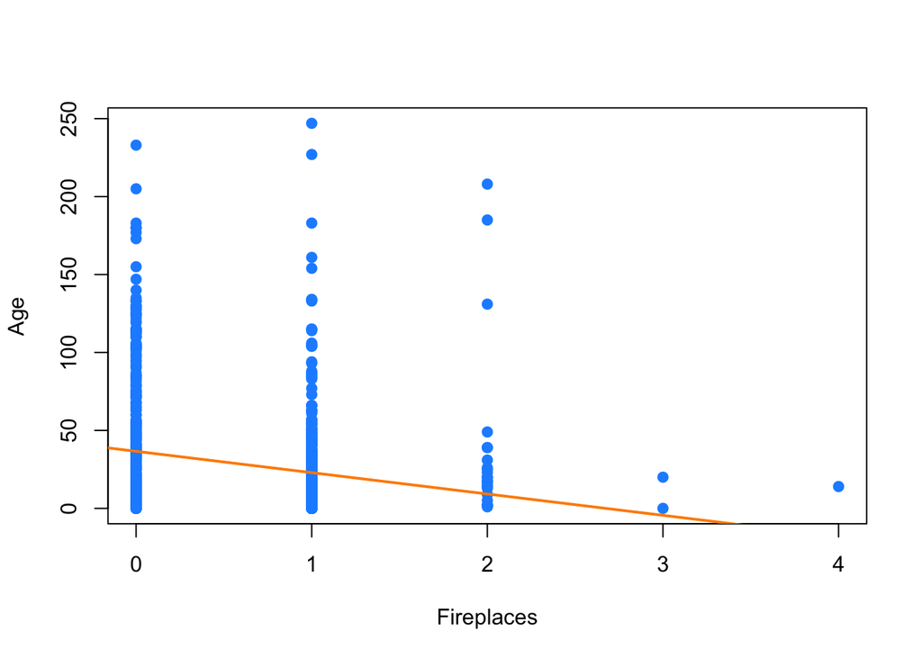

```r
plot(Age ~ Fireplaces,
     data = housing,
     col = "dodgerblue", pch = 20, cex = 1.5)
abline(age_fire, col = "darkorange", lwd = 2)
```

```r
sqrt(mean(resid(age_fire)^2))
```

```
## [1] 34.08795
```

```r
bedroom_bathroom = lm(log(Bedrooms) ~ log(Bathrooms), data = housing)
summary(bedroom_bathroom)
```

```
##
## Call:
## lm(formula = log(Bedrooms) ~ log(Bathrooms), data = housing)
##
## Residuals:
##      Min       1Q   Median       3Q      Max
## -0.93256 -0.13645  0.03219  0.15123  0.67687
##
## Coefficients:
##                Estimate Std. Error t value Pr(>|t|)
## (Intercept)     0.93256    0.01294   72.04   <2e-16 ***
## log(Bathrooms)  0.33013    0.01860   17.75   <2e-16 ***
## ---
## Signif. codes:  0 '***' 0.001 '**' 0.01 '*' 0.05 '.' 0.1 ' ' 1
##
## Residual standard error: 0.2183 on 1055 degrees of freedom
## Multiple R-squared:   0.23,  Adjusted R-squared:  0.2293
## F-statistic: 315.1 on 1 and 1055 DF,  p-value: < 2.2e-16
```

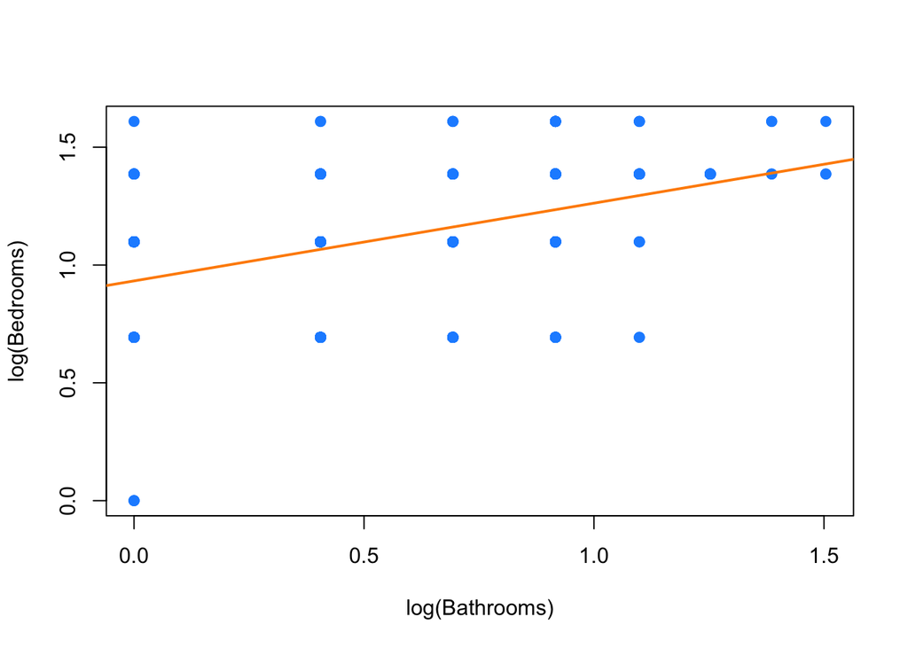

```r
plot(log(Bedrooms) ~ log(Bathrooms),
     data = housing,
     col = "dodgerblue", pch = 20, cex = 1.5)
abline(bedroom_bathroom, col = "darkorange", lwd = 2)
```

```r
sqrt(mean(resid(bedroom_bathroom)^2))
```

```
## [1] 0.2181338
```

# Result

# Appendix

## Team Members

| Name | NetID |
| --- | --- |
| Rebecca (YaoJia) Chen | yrchen2 |
| Haofei Xu | haofeix2 |
| Linda (Xinyi) Yuan | xinyiy6 |